# CIBERlite: convergent validity

Gjalt-Jorn Peters & Rik Crutzen

14:38:11 on 2018-08-01 CEST (GMT+0200)

# Introduction

## Status of this file

This is the R Markdown file for the “CIBERlite: convergent validity” study. This study is a project of the Academy of Behavior Change. The canonical URL for this study is https://ciberlite.com/convergent-validity. Initially, this will resolve to the study’s Open Science Framework repository (https://osf.io/pemfz/), but in time it may point to a website to facilitate CIBERlite implementation by prevention organisations. The study’s OSF repository (repo) synchronises with the GitHub repo at https://github.com/academy-of-behavior-change/ciberlite-convergent-validity.

Note that because this is a living project, you will probably need the most up-to-date version of the `userfriendlyscience` package (*if* that has been submitted to CRAN yet). See https://userfriendlyscience.com for instructions as to how to install it.

## Background of the project

A second goal of CIBERlite, but only one that only emerged as we were working on this project, is to work towards a framework for calibrating determinant operationalisations over behaviors and populations.

The preregistration form for this study is at https://osf.io/pemfz/register/hvkzr. That is a good place to start before reading further.

## License of these materials

This file and the other materials in the OSF and GitHub repo’s associated with this project are licensed under the Creative Commons attribution share alike license (CC-BY-NC-SA; see http://creativecommons.org/licenses/by-nc-sa/4.0/). This means that you are allowed to copy and distribute these files freely, but you’re not allowed to sell them. It also means that if you create derivative works (i.e. if you remix, transform, or build upon the material), you must distribute your contributions under the same license as the original.

# Setup of R environment

Here, we configure some settings and load the required R packages.

```r
########################################################################
### Packages
########################################################################

if (!require('userfriendlyscience', quietly = FALSE)) {
  stop("You need to have the userfriendlyscience package installed!");
}
safeRequire('here');
safeRequire('knitr');
safeRequire('pander');
safeRequire('data.tree');
safeRequire('tidyverse');
safeRequire('gridExtra');
safeRequire('readODS');

########################################################################
### Settings
########################################################################

knitr::opts_chunk$set(echo=FALSE);
knitr::opts_chunk$set(cache=FALSE);
knitr::opts_chunk$set(comment=NA);

options(width = 160);
options(xtable.type = "html");
panderOptions('knitr.auto.asis', FALSE);
panderOptions('table.split.table', Inf);

options(ufs.debug = FALSE);

########################################################################
### Set the variables with the paths and filenames
########################################################################

dataPath <- here::here('results-data-raw');
processedDataPath <- here::here('results-data-processed');
outputPath <- here::here('results-output');

privateDataFileRegEx <- 'survey_797479_R_data_file_\\[PRIVATE-version]';
publicDataFileRegEx <- 'survey_797479_R_data_file_\\[PUBLIC-version]';
dataLoadScriptName <- 'survey_797479_R_syntax_file.R';

########################################################################
### Configure dataset characteristics
########################################################################

categoricalQuestions <- c('sex',
                          'education',
                          'country');

dataDeletionVarCode <- "dataMustBeDeleted";
dataDeletionSubQuestionCode <- "delete";
dataDeletionVarValue <- "2";
privateFileIdentificationString <- "PRIVATE-";
publicFileIdentificationString <- "PUBLIC-";

### These are the behaviors in this study
behaviors <- c("alcohol", "coffee", "smoking",
               "exercise", "marathon");

########################################################################
### Specific function and variable definitions
########################################################################

### Load spatial and inhabitation density data for postcodes
pcDat <- data.frame(postcode =  c(10, 11, 12, 13, 14, 15, 16, 17, 18, 19, 20, 21, 22, 23, 24, 25, 26, 27, 28, 29, 30, 31, 32, 33, 34, 35, 36, 37, 38, 39, 40, 41, 42, 43, 44, 45, 46, 47, 48, 49, 50, 51, 52, 53, 54, 55, 56, 57, 58, 59, 60, 61, 62, 63, 64, 65, 66, 67, 68, 69, 70, 71, 72, 73, 74, 75, 76, 77, 78, 79, 80, 81, 82, 83, 84, 85, 86, 87, 88, 89, 90, 91, 92, 93, 94, 95, 96, 97, 98, 99),
                    lat = c(52.3678024669572, 52.3455635724132, 52.2501138713815, 52.3585841561271, 52.3735313335077, 52.4657234141959, 52.6830233696612, 52.8198812701222, 52.639550621648, 52.4950689582663, 52.3856186275876, 52.2953703699729, 52.1292546069181, 52.161384292839, 52.1219310706044, 52.0684520747327, 52.0033402777623, 52.0563875683333, 52.0012138989129, 51.8986006453915, 51.9193874565932, 51.9106309680917, 51.8140252861272, 51.8149115339002, 52.0425276819077, 52.0934177824935, 52.1735550175486, 52.1523629740434, 52.223637595618, 52.0279361091616, 51.9054273863578, 51.915733212362, 51.8214914178629, 51.543768240357, 51.4892107569007, 51.3084062814104, 51.5147702745308, 51.5716616062968, 51.5747515937066, 51.6667015879655, 51.5549425996685, 51.6281052353666, 51.6782564610835, 51.7656968848253, 51.6366014520531, 51.3773177941176, 51.4597694831659, 51.4561668812027, 51.5657913844856, 51.3673618493396, 51.2198301363131, 51.0044676214146, 50.8399895742703, 50.8892820844185, 50.8949574101474, 51.8139166230324, 51.8719970570536, 52.0258947138041, 51.9758504258543, 51.9808607088139, 51.9332441744435, 52.0118296962591, 52.1317418255387, 52.2066433697708, 52.2679816480253, 52.2558617315003, 52.3814194800148, 52.5961180135375, 52.7757597738851, 52.7160955644958, 52.4859065597251, 52.3693689406752, 52.5307269978189, 52.747461266424, 52.9652050745035, 52.9094416896853, 53.026376169836, 53.0313126432087, 53.2061363841068, 53.2017360846828, 53.2012055919669, 53.3555306903419, 53.166322821535, 53.1329669620421, 52.9877145107302, 52.9592909500932, 53.1332498567166, 53.2160520411166, 53.2440706462868, 53.3389037688135),
                    lon = c(4.88265296235255, 4.92048844018191, 5.20016981451878, 5.19692084970926, 4.96119798514817, 4.80566389502282, 5.11709329957045, 4.82220173575481, 4.73944411275498, 4.65711588941856, 4.63162288403011, 4.61303752028347, 4.3931852765124, 4.51168737011436, 4.63123989742888, 4.29372836005594, 4.33979586949051, 4.54021535596711, 4.73452186458328, 4.61368753801164, 4.49164782911762, 4.33928060878812, 4.2829687516736, 4.69600707584607, 4.99433000213242, 5.1095360206426, 4.97767698785868, 5.32054575304636, 5.48553597975019, 5.38238247299173, 5.45767067590559, 5.18795319713936, 4.97922665393621, 3.66936390672942, 3.90470966273241, 3.79097509053622, 4.27097697088173, 4.50517380658332, 4.74318639278844, 4.84195733671919, 5.09638240155648, 5.00860229089637, 5.30772679514586, 5.46688460609673, 5.63639617277517, 5.38279769544641, 5.47322994631042, 5.70431204157048, 5.9899379118757, 6.10424312097242, 5.85259175752854, 5.83577253884675, 5.74094339560624, 5.93323298584949, 5.97735784656114, 5.86784740403142, 5.74067359988713, 5.66032248729721, 5.89735875172907, 6.07948324211148, 6.33285411615927, 6.63091103024003, 6.31125395599666, 5.99205974571486, 6.40504947547195, 6.88122082304407, 6.67828479011708, 6.54877480129994, 6.90784259899023, 6.35342435589724, 6.01919757591485, 6.13112521172761, 5.68385478833178, 5.90341298721153, 6.0379057614734, 5.70428744074426, 5.65270524920928, 5.48206467307413, 5.45632660753506, 5.80358549811831, 5.74644474592641, 5.95945766858073, 6.08416956383472, 6.39046332177174, 6.58818166864684, 6.97818596118079, 6.91595201151317, 6.57429045577232, 6.33816563415263, 6.72160735648967),
                    inhabitationDensity = c(6412, 1857, 1831, 1451, 1519, 1679, 1010, 965, 1726, 1706, 2775, 1395, 2121, 2432, 1438, 4891, 1956, 1982, 1693, 1533, 4041, 2432, 1141, 1970, 1282, 3329, 1001, 1175, 1527, 1147, 782, 798, 829, 1101, 672, 559, 1049, 994, 1598, 1149, 2027, 989, 1441, 886, 782, 926, 1766, 1032, 651, 1044, 824, 1010, 1522, 810, 1487, 1783, 715, 1424, 1690, 894, 762, 780, 854, 1464, 1166, 1601, 926, 497, 644, 769, 1267, 538, 1176, 623, 705, 523, 1068, 422, 614, 2268, 337, 366, 674, 600, 790, 508, 703, 2596, 253, 484));

### The inhabitation density is the 'environment address density'. According
### to the Dutch Central Bureau for Statistics, these densities can be
### meaningfully categorized into five degrees of urbanisation:
###
### > 2500 = extremely urban
### > 1500 = very urban
### > 1000 = urban
### > 500  = rural
### < 500  = very rural

pcDat$urbanisation <- cut(pcDat$inhabitationDensity,
                          breaks=c(0, 500, 1000, 1500, 2500, max(pcDat$inhabitationDensity)),
                          labels=c("Very rural",
                                   "Rural",
                                   "Urban",
                                   "Very urban",
                                   "Extremely urban"),
                          ordered_result = TRUE);
```

# Determinant structures

This command builds the determinant structures that we will analyse. This uses very much in-progress code from the `userfriendlyscience` package that leverages the `data.tree` package to build a hierarchy of determinants and sub-determinants.

# Data import and preprocessing

This includes sanitizing the private data files for publication.

```
Read data file 'survey_797479_R_data_file_[PRIVATE-version].csv'.

Identified 31 participants who indicated they want their data to be deleted, specifically, the following lines of the original raw dataset:

'6', '10', '16', '21', '36', '37', '49', '54', '60', '66', '84', '87', '96', '97', '100', '101', '103', '104', '107', '109', '117', '129', '138', '143', '145', '149', '159', '160', '164', '166' & '168'

Stored data file 'survey_797479_R_data_file_[PUBLIC-version].csv'.
```

# Sample description

The dataset (after sanitization) has 146 rows. 126 rows submitted the complete survey (i.e. have a non-missing value for `submitdate`). Note that providing demographic data was optional, so less data may be available for the demographic variables (age, sex, education, country, and region).

## Age

```
**Describing the central tendency:**


----------------------------------------
 mean    median   mode    95% CI mean
------- -------- ------ ----------------
 35.92     36      24    [33.87; 37.97]
----------------------------------------



**Describing the spread:**


-----------------------------
  var     sd     iqr    se
------- ------- ----- -------
 129.5   11.38   20    1.035
-----------------------------



**Describing the range:**


---------------------
 min   q1   q3   max
----- ---- ---- -----
 18    25   46   63
---------------------



**Describing the distribution shape:**


-------------------------------
 skewness   kurtosis     dip
---------- ---------- ---------
  0.2812       -1      0.02893
-------------------------------



**Describing the sample size:**


---------------------
 total   NA.   valid
------- ----- -------
  146    25     121
---------------------
```

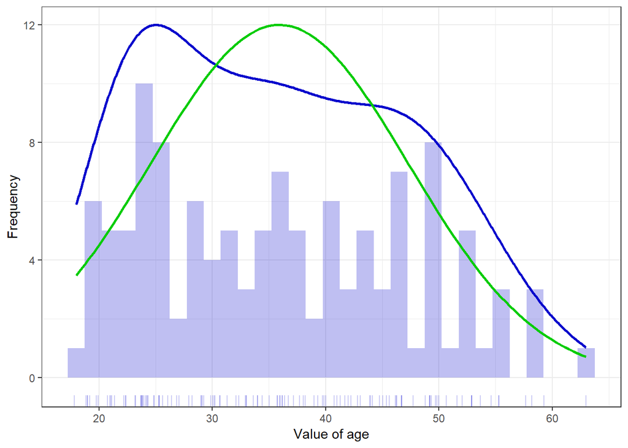

## Sex

```
-----------------------------------------------------------------------
      &nbsp;        Frequencies   Perc.Total   Perc.Valid   Cumulative
------------------ ------------- ------------ ------------ ------------
    **Vrouw**           92            63           76           76

     **Man**            29           19.9          24          100

 **Total valid**        121          82.9         100

 **NA (missing)**       25           17.1

    **Total**           146          100
-----------------------------------------------------------------------
```

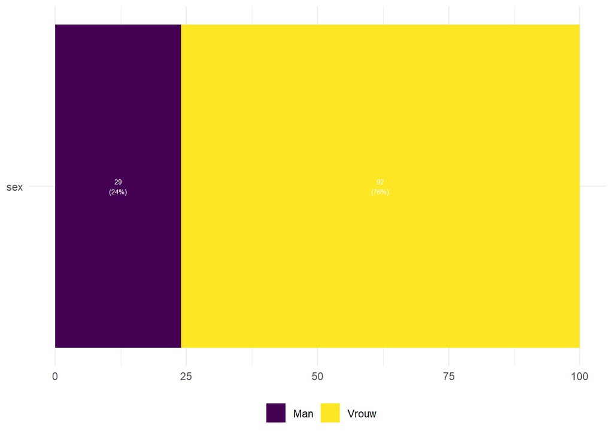

## Education

```
-------------------------------------------------------------------------------------
             &nbsp;               Frequencies   Perc.Total   Perc.Valid   Cumulative
-------------------------------- ------------- ------------ ------------ ------------
         **HAVO / VWO**               10           6.8          8.5          8.5

 **MBO (bijvoorbeeld een ROC)**        3           2.1          2.6          11.1

            **HBO**                   44           30.1         37.6         48.7

 **WO (bijvoorbeeld een MSc of        60           41.1         51.3         100
             PhD)**

        **Total valid**               117          80.1         100

        **NA (missing)**              29           19.9

           **Total**                  146          100
-------------------------------------------------------------------------------------
```

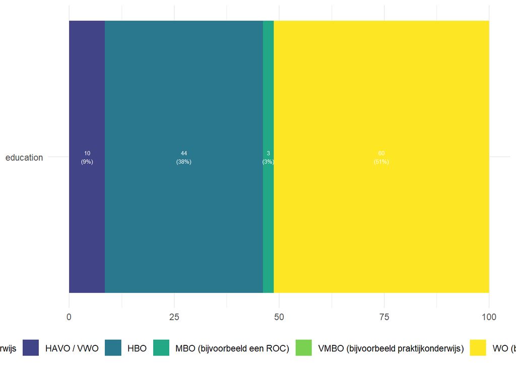